# Reproducible Research - Peer Assessment 1 - Activity Monitoring

## Data

The data for this assignment can be downloaded from the course web site:

Dataset: **[Activity monitoring data](https://d396qusza40orc.cloudfront.net/repdata%2Fdata%2Factivity.zip)**

The variables included in this dataset are:

- **steps**: Number of steps taking in a 5-minute interval (missing values are coded as NA)
- **date**: The date on which the measurement was taken in YYYY-MM-DD format
- **interval**: Identifier for the 5-minute interval in which measurement was taken

## Prerequiste for reporducing the data

### Load the libraries

```r
library(ggplot2)
library(scales)
library(Hmisc)
getwd()
```

```
## [1] "C:/Praveen/Coursera/Reproducible Research"
```

## Loading and preprocessing the data

```r
unzip("repdata_data_activity.zip")
repdata <- read.csv("activity.csv", colClasses = c("integer", "Date", "factor"))
#repdata$month <- as.numeric(format(repdata$date, "%m"))
head(repdata)
```

```
##   steps       date interval
## 1    NA 2012-10-01        0
## 2    NA 2012-10-01        5
## 3    NA 2012-10-01       10
## 4    NA 2012-10-01       15
## 5    NA 2012-10-01       20
## 6    NA 2012-10-01       25
```

```r
repdataWithoutNA <- na.omit(repdata)
head(repdataWithoutNA)
```

```
##     steps       date interval
## 289     0 2012-10-02        0
## 290     0 2012-10-02        5
## 291     0 2012-10-02       10
## 292     0 2012-10-02       15
## 293     0 2012-10-02       20
## 294     0 2012-10-02       25
```

## 1. What is mean total number of steps taken per day?

### 1.a. Make a histogram of the total number of steps taken per day

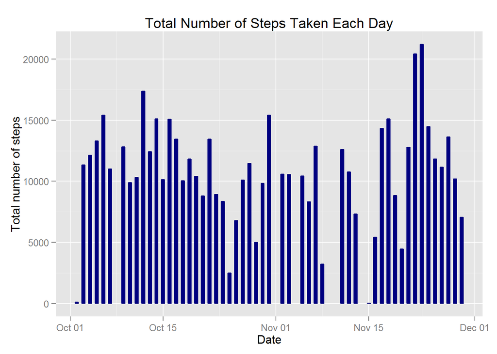

```r
ggplot(repdataWithoutNA, aes(date, steps)) + geom_histogram(stat = "identity", colour = "navy blue", fill = "navy blue", width = 0.5) + labs(title = "Total Number of Steps Taken Each Day", x = "Date", y = "Total number of steps")
```

### 1.b. Calculate and report the mean and median of the total number of steps taken per day

```r
totalSteps <- aggregate(repdataWithoutNA$steps, list(Date = repdataWithoutNA$date), FUN = "sum")$x
mean(totalSteps)
```

```
## [1] 10766.19
```

```r
median(totalSteps)
```

```
## [1] 10765
```

## 2. What is the average daily activity pattern?

### 2.a. Make a time series plot (i.e. type = “l”) of the 5-minute interval (x-axis) and the average number of steps taken, averaged across all days (y-axis)

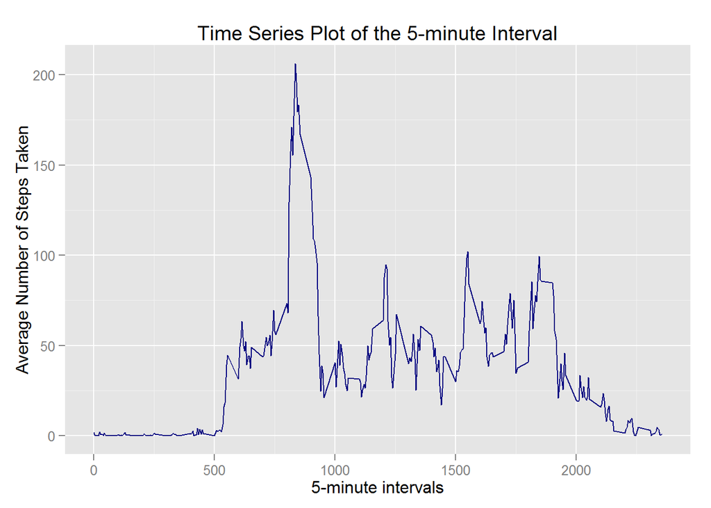

```r
avgSteps <- aggregate(repdataWithoutNA$steps, list(interval = as.numeric(as.character(repdataWithoutNA$interval))), FUN = "mean")
names(avgSteps)[2] <- "meanOfSteps"
ggplot(avgSteps, aes(interval, meanOfSteps)) + geom_line(color = "navy blue", size = 0.5) + labs(title = "Time Series Plot of the 5-minute Interval", x = "5-minute intervals", y = "Average Number of Steps Taken")
```

### 2.b. Which 5-minute interval, on average across all the days in the dataset, contains the maximum number of steps?

```r
avgSteps[avgSteps$meanOfSteps == max(avgSteps$meanOfSteps), ]
```

```
##     interval meanOfSteps
## 104      835    206.1698
```

## 3. Imputing missing values

### 3.a. Calculate and report the total number of missing values in the dataset (i.e. the total number of rows with NAs)

```r
sum(is.na(repdata))
```

```
## [1] 2304
```

### 3.b. Devise a strategy for filling in all of the missing values in the dataset. Create a new dataset that is equal to the original dataset but with the missing data filled in

```r
repdataModified <- repdata
for (i in 1:nrow(repdataModified)) {
    if (is.na(repdataModified$steps[i])) {
        repdataModified$steps[i] <- avgSteps[which(repdataModified$interval[i] == avgSteps$interval), ]$meanOfSteps
    }
}
```

### 3.c. Make a histogram of the total number of steps taken each day and Calculate and report the mean and median total number of steps taken per day.

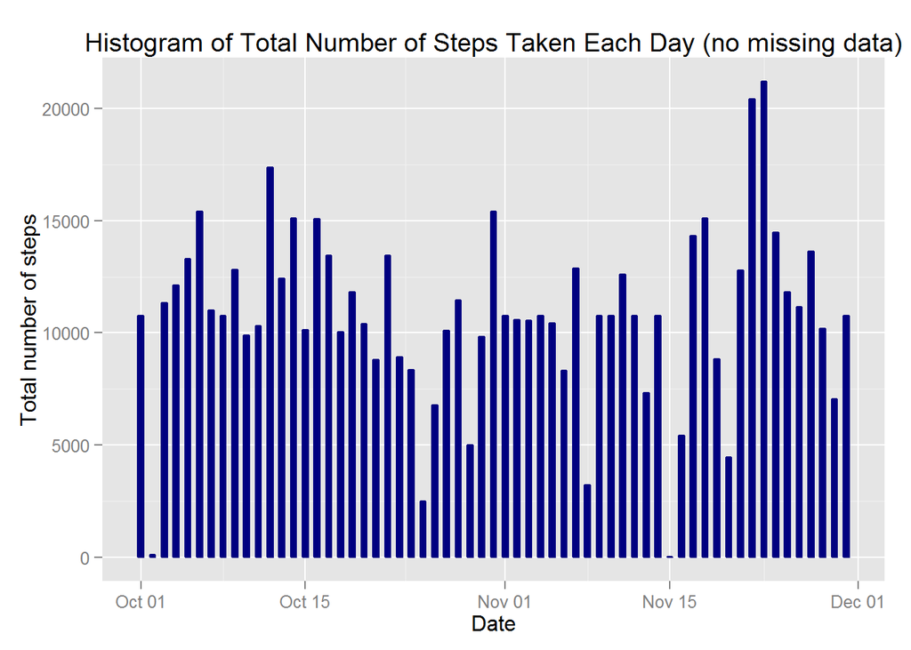

```r
ggplot(repdataModified, aes(date, steps)) + geom_histogram(stat = "identity", colour = "navy blue", fill = "navy blue", width = 0.5)  + labs(title = "Histogram of Total Number of Steps Taken Each Day (no missing data)", x = "Date", y = "Total number of steps")
```

Mean total number of steps taken per day:

```r
newTotalSteps <- aggregate(repdataModified$steps,                            list(Date = repdataModified$date),
                           FUN = "sum")$x
newMean <- mean(newTotalSteps)
newMean
```

```
## [1] 10766.19
```

Median total number of steps taken per day:

```r
newMedian <- median(newTotalSteps)
newMedian
```

```
## [1] 10766.19
```